# Tracing mitochondrial lineages in the Norfolk Island pedigree

Miles Benton

25/06/2018

last modified: 2019-02-12

# Overview

This is a set of functions designed to identify founding females in a pedigree, extracting their maternal lineages and plotting these sub-pedigrees. The driving force behind the development of this piece of work was to track mitochondrial inheritence patterns, but with some additional tweaks it could have many other uses.

Here is an example pedigree diagram (from the Norfolk Island population) showing founding Polynesian maternal lineages in colour.

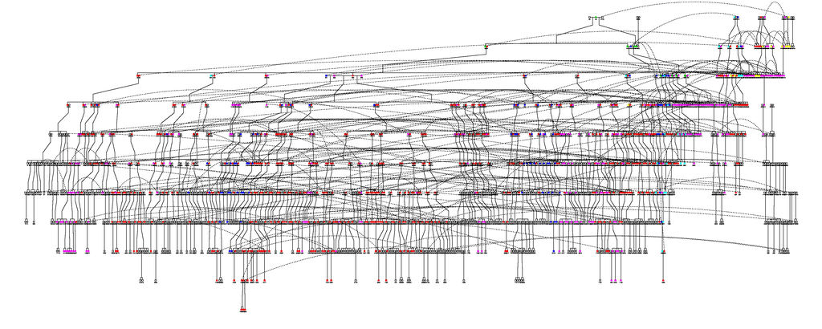

*source:* [Benton *et al.,* 2015. *‘Mutiny on the Bounty’: The Genetic History of Norfolk Island reveals extreme gender biased admixture*](http://www.investigativegenetics.com/content/6/1/11)

The idea behind the image is clear, however it is rather difficult to easily visualise the separate lineages. Hence I developed the following approach in R using a combination of existing packages and some custom functions. Using the below we now have the ability to:

- extract all mothers from a pedigree file
- trace back a mothers ID to her maternal founder within the pedigree
  - identify all such maternal founders
- explore the frequency of these founders lineages (identifying those that are largest/smallest, etc.)
- given a founder ID, extract her maternal lineage
- extract a given lineage and create a sub-pedigree plot

## Load the required packages

```r
# load packages
require(kinship2)
require(pedigree)
require(tidyverse)
```

## Load the pedigree data

```r
# load data
setwd('/data/PostDoc/NI_pedigree')
# load pedigree
niped <- read.table('NI_UUID_pedigree.ped', head = F)
# add colnames for ease of use
colnames(niped) <- c('FID', 'IID', 'PID', 'MID', 'SEX', 'PHENO')
```

The pedigree is contained in a .ped (pedigree), very similar to the plink file format of the same name. Here is the head of the pedigree file once loaded into R, it has 6 columns:

```r
# head of the pedigree
head(niped)
```

```
##   FID    IID    PID    MID SEX PHENO
## 1   1 110630    790    800   2    -9
## 2   1 110850 111740 333130   2    -9
## 3   1 111280    933     59   2    -9
## 4   1 111830 169270 400523   2    -9
## 5   1 310881      0      0   2    -9
## 6   1 343481   1716 319731   2    -9
```

Here is a breakdown of the columns:

- **FID** = family ID (as NI is one large family this is 1 for everybody), if you imagine there being separate families, say trios, then each would get assigned a different number.
- **IID** = individual ID (sample ID)
- **PID** = paternal ID (father)
- **MID** = maternal ID (mother)
- **SEX** = obvious (1 is male, 2 is female)
- **PHENO** = phenotype data, this is set to missing (-9) because there is no analysis to be performed. One might include something like BMI in this column when performing an association analysis using a tool like plink.

## 1. `get_mothers()`

```r
# define unique mothers
get_mothers <- function(pedigree) {
  pedigree %>%
    filter(SEX == 2) %>%
    select(MID) %>%
    unique %>%
    filter(. > 0) %>%
    as.matrix %>%
    as.list
}
```

```r
# get list of all mothers in pedigree
mothers <- get_mothers(pedigree = niped)
```

## 2. `trace_mother()`

```r
# function to trace a 'founding' mother
trace_mother <- function(pedigree, motherID) {
  results <- NULL
  x <- motherID
  while (x != 0) {
    z <- x
    x <- pedigree %>%
      filter(IID == x) %>%
      select(MID) %>%
      as.character
    results <- rbind(results, data.frame(IID = z, MID = x))
  }
  results <- results[dim(results)[1]:1,]
  return(results)
}
```

We can apply the `trace_mother()` function on a single sample:

```r
# single use of the function, direct maternal line back to founder from a single female
trace_mother(pedigree = niped, motherID = '400440')
```

```
##       IID    MID
## 10    691      0
## 9      34    691
## 8     253     34
## 7     449    253
## 6     453    449
## 5     342    453
## 4     345    342
## 3  400523    345
## 2  111830 400523
## 1  400440 111830
```

Probably more useful, however, is the ability to run this across all mothers within a pedigree:

```r
# apply across all mothers and get lists tracing back to 'founding' individuals
mother_lists <- lapply(mothers, trace_mother, pedigree = niped)
```

## 3. `founding_mothers()`

```r
# get all unique maternal founders
founding_mothers <- function(mother_lists) {
  sapply(mother_lists, '[[',1) %>%
    sapply(., '[[',1) %>%
    unique %>%
    as.numeric %>%
    sort
}
```

```r
# use the above function to get a sorted vector of founding mothers
mt_founders <- founding_mothers(mother_lists = mother_lists)
```

## 4. `maternal_freq()`

```r
# identify the mothers with largest maternal lines
maternal_freq <- function(mother_list, frequency, plot = FALSE) {
  # generate freq table
  results <-
    sapply(mother_list, '[[',1) %>%
    sapply(., '[[',1) %>%
    as.data.frame %>%
    rename(., Maternal_ID = 1) %>%
    mutate_at(1, as.character) %>%
    plyr::count() %>%
    arrange(-freq) %>%
    filter(freq >= frequency)
  # plot if required
  if(plot == TRUE) {
    return(list(results, barplot(results$freq, names.arg = results$Maternal_ID, main = 'most frequent maternal founders',
                                 xlab = 'Maternal ID', ylab = 'Freq', las = 2, col = 'cadetblue')))
  } else {
    return(results)
  }
}
```

This function in practice:

```r
# provide a threshold and create a table of maternal frequencies
maternal_freq(mother_list = mother_lists, frequency = 3)
```

```
##    Maternal_ID freq
## 1          691  115
## 2          694   58
## 3          242   26
## 4           13    8
## 5         1597    8
## 6          490    7
## 7          522    6
## 8         1878    5
## 9           23    5
## 10         208    4
## 11        2212    4
## 12        3018    4
## 13         219    3
## 14        2462    3
```

…and with a plot:

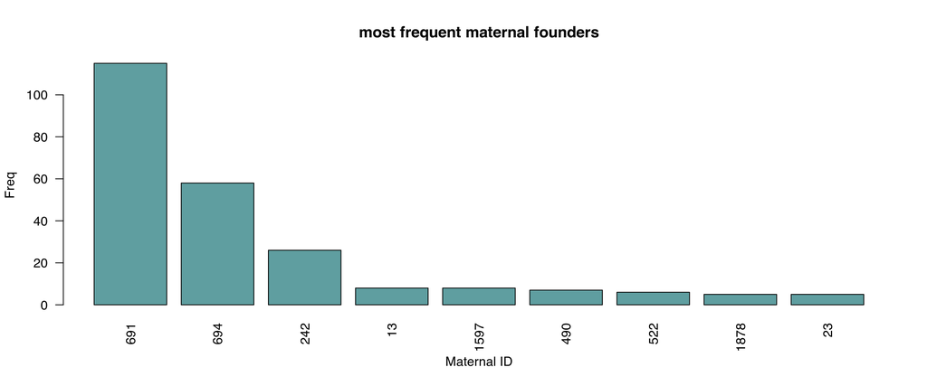

```r
# create plot if required
maternal_freq(mother_list = mother_lists, frequency = 5, plot = T)
```

## 5. `trace_maternal_line()`

```r
# starting with a MID trace all maternal descendents
trace_maternal_line <- function(pedigree, motherID) {
  x <- motherID
  results <- list(as.numeric(x)) # add founding mother as first entry in list
  counter <- 1
  while (length(x) > 0) {
    counter <- counter + 1
    # x <- pedigree[pedigree$MID %in% x & pedigree$SEX == 2,]$IID # this will pull only female offspring of the searched mother
    x <- niped[niped$MID %in% x,]$IID # this will pull all offspring
    results[[counter]] <- x
  }
  # remove empty entry and return results
  return(results[-length(results)])
}
```

```r
# examples
trace_maternal_line(pedigree = niped, motherID = '691') # red in pedigree plot
```

```
## [[1]]
## [1] 691
##
## [[2]]
## [1]  34 532 692 696
##
## [[3]]
##  [1]   31   32  251  252  253  255  256  326  533  535  536  537 2111
##
## [[4]]
##  [1]   22  147  148  150  151  157  176  249  250  279  335  426  449  472
## [15]  541  542  543  626  627  629  630  635  643  644  710 1030 1031 1032
## [29] 1033 1039 1040 1162 1674 2064 2113 2114 2115 2116 2119 2131 2132 2133
## [43] 2135
##
## [[5]]
##  [1]   56   57  161  163  286  315  341  376  408  412  414  427  429  430
## [15]  434  435  441  450  451  452  453  454  456  475  481  651  711  713
## [29]  716  718  727  777  780  782  821  822  824  911  912  917  973 1041
## [43] 1079 1081 1128 1163 1164 1167 1170 1172 1598 1894 1902 1917 2124 2125
## [57] 2127 2222 2345 2354 2358 2360 2417 2420 5044 5082 5092
##
## [[6]]
##  [1] 168050 255670 400093 125660 320320 317710     46     59     60     61
## [11]     62    199    316    318    342    377    391    482    496    519
## [21]    520    655    719    721    722    730    731    732    826    829
## [31]    859    860    896    934    946    968    974   1087   1106   1108
## [41]   1129   1130   1131   1132   1175   1179   1181   1196   1270   1298
## [51]   1431   1437   1438   1522   1600   1604   1606   1611   1614   1644
## [61]   1645   1646   1661   1877   1896   1904   1906   1910   1918   2009
## [71]   2228   2288   2427   2574   2575   2578   2579   2580   2656   3158
## [81]   3362   4050   4886
##
## [[7]]
##  [1] 111280 111890 111990 110820 320620 124670 362060 125580 328820 315981
## [11] 400107 400389 330050 311760 168180 316910 311360 211340 217310 212910
## [21] 245120 400096 400226 400301 400370 400519 400520     63 400012    320
## [31]    344    345    346    656    723    897    935 400115   1091   1115
## [41]   1134   1198   1230   1263   1321   1322   1323   1324   1524   1542
## [51]   1615   1659   1664   1667   1669   1672   1720   1721   1747   1781
## [61]   1846   1849   1852   1925   1953   2017   2430   2445 400087   2602
## [71]   2603   2618   2621   2623   2757   2760   2911   2992   2994   2997
## [81]   4881   5310
##
## [[8]]
##  [1] 317801 331100 111460 314210 336510 310601 310121 322861 310711 124480
## [11] 311160 336600 366851 228260 271360 255711 400024 400070 400162 400232
## [21] 400381 400523 216261 400785 311700 110550 310820 320450 344870 343430
## [31] 125270 312370 316320 312930 317650 169020 310040 169270 232420 228350
## [41] 215590 212390 400011 400305 400643 400671    354    503   1005   1547
## [51]   1576   1616   1802   1851   1853   1926   1927 400726   2667   4865
##
## [[9]]
##  [1] 111830 317941 110500 111770 312801 125900 136150 375731 332031 311071
## [11] 214050 216640 400310 400315 320490 312590 314200 219560 267620 228151
## [21] 227220 400194 400341 400554 400646 400660 400672 400765 400659 400317
##
## [[10]]
## [1] 111800 217943 212804 400208 400440 400441 269400
```

```r
trace_maternal_line(pedigree = niped, motherID = '242') # darkblue in pedigree plot
```

```
## [[1]]
## [1] 242
##
## [[2]]
## [1] 244 245 246 247 248 528
##
## [[3]]
##  [1]  258  259  261  262  267  425  446  447  448 2150
##
## [[4]]
##  [1]  190  328  333  334  458  459  470 1063 2186 2188 2193 2431 2741
##
## [[5]]
##  [1]  193  194  195  198  488  868  873  875 1054 1067 1271 2434 2694 2840
## [15] 2843 2845 4949
##
## [[6]]
##  [1] 344050 168720 400311    478    479    783   1071   1117   1187   1188
## [11]   1189   1190   3047   4870
##
## [[7]]
## [1] 356930 111090 250921 400634 400399   1118
##
## [[8]]
## [1] 400644 327200 400619
```

```r
trace_maternal_line(pedigree = niped, motherID = '522') # lightblue in pedigree plot
```

```
## [[1]]
## [1] 522
##
## [[2]]
## [1] 523 524 525
##
## [[3]]
## [1]  424 2106 2109
##
## [[4]]
## [1] 2155 2156 4980
##
## [[5]]
## [1] 4888 4951 4987
##
## [[6]]
## [1] 4871 4877
##
## [[7]]
## [1] 4864
```

```r
trace_maternal_line(pedigree = niped, motherID = '1597')
```

```
## [[1]]
## [1] 1597
##
## [[2]]
## [1]  288 2334 2335
##
## [[3]]
## [1]  289  291 2749 2750 2752 3055
##
## [[4]]
## [1] 301001 400521 400543    307    308    878   1223   1125
##
## [[5]]
## [1] 301008 400470 334380 316400 301007 125140 313570 400104
```

```r
trace_maternal_line(pedigree = niped, motherID = '13')
```

```
## [[1]]
## [1] 13
##
## [[2]]
## [1] 364020 312960 125850 168790      9     15     17     19     20
##
## [[3]]
##  [1] 333760 333130 212771 213991 319420 345601 316160 316960 219390    112
## [11] 213992
##
## [[4]]
## [1] 110850 338630 400516 400263 400512
```

```r
# count female decendents
trace_maternal_line(pedigree = niped, motherID = '691') %>% unlist %>% length
```

```
## [1] 390
```

```r
trace_maternal_line(pedigree = niped, motherID = '694') %>% unlist %>% length
```

```
## [1] 167
```

```r
trace_maternal_line(pedigree = niped, motherID = '242') %>% unlist %>% length
```

```
## [1] 70
```

```r
trace_maternal_line(pedigree = niped, motherID = '13') %>% unlist %>% length
```

```
## [1] 26
```

```r
trace_maternal_line(pedigree = niped, motherID = '1597') %>% unlist %>% length
```

```
## [1] 26
```

```r
trace_maternal_line(pedigree = niped, motherID = '490') %>% unlist %>% length
```

```
## [1] 22
```

```r
trace_maternal_line(pedigree = niped, motherID = '522') %>% unlist %>% length
```

```
## [1] 16
```

```r
trace_maternal_line(pedigree = niped, motherID = '1954') %>% unlist %>% length
```

```
## [1] 4
```

## 6. `split_maternal_ped()`

```r
# create sub-pedigrees of mt lineages
# need kinship2 and pedigree for this function
# I will work on building in package checking later
split_maternal_ped <- function(pedigree, motherID) {
    # determine 'affecteds'
  search_IDs <- trace_maternal_line(pedigree = pedigree, motherID = motherID) %>% unlist
    # pedigree splitting
  ped <- data.frame(pedigree$IID, pedigree$PID, pedigree$MID)
  (ord <- orderPed(ped))
  ped <- ped[order(ord),]
  # trim out only 'affecteds' - all female descendants of a given founder
  yn <- trimPed(ped, data = (ped$pedigree.IID %in% search_IDs), ngenback = 0)
  ped <- ped[yn,]
  colnames(ped) <- c('IID', 'PID', 'MID')
  ped <- merge(ped, pedigree, by = c('IID', 'PID', 'MID'), sort = F)
  # get dad ids
  dad.ids <-
    ped %>%
    filter(PID > 0) %>%
    select(PID) %>%
    unlist %>%
    unique
  # check if any of these are already in ped, if so remove
  dad.ids <- dad.ids[!(dad.ids %in% ped$IID)]
  # grab father information and set thier PID and MID to 0 for plotting purposes
  res.out <- pedigree %>% filter(IID %in% dad.ids)
  res.out$PID = 0
  res.out$MID = 0
  # add father information back into the ped
  ped <- rbind(res.out, ped)
  # create a pedigree to plot using kinship2 function
  test.ped <- pedigree(id = ped$IID, dadid = ped$PID, momid = ped$MID, sex = ped$SEX)
  # plotting
  return(list(plot.pedigree(test.ped, affected = ped$SEX, cex = 0.8, symbolsize = 0.8, width = 40, align = T), ped[-6]))
}
```

A few tests of the above:

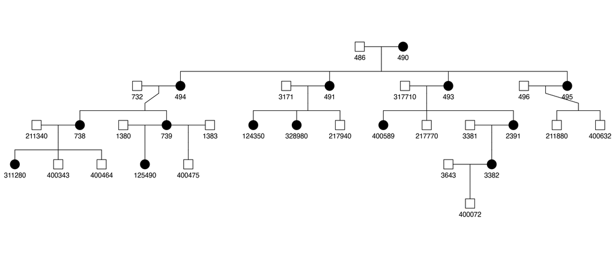

```r
# split out the given maternal lineage and create a pedigree diagram
split_maternal_ped(pedigree = niped, motherID = '490')
```

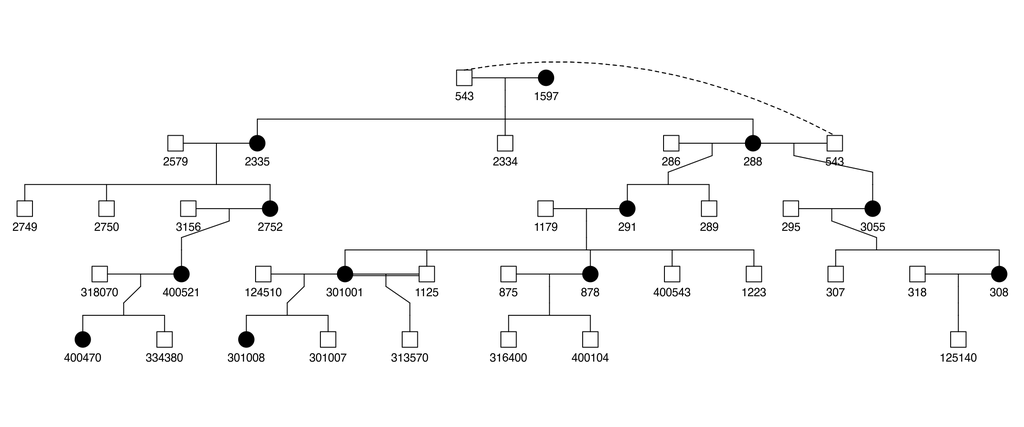

```r
# split out the given maternal lineage and create a pedigree diagram
split_maternal_ped(pedigree = niped, motherID = '1597')
```

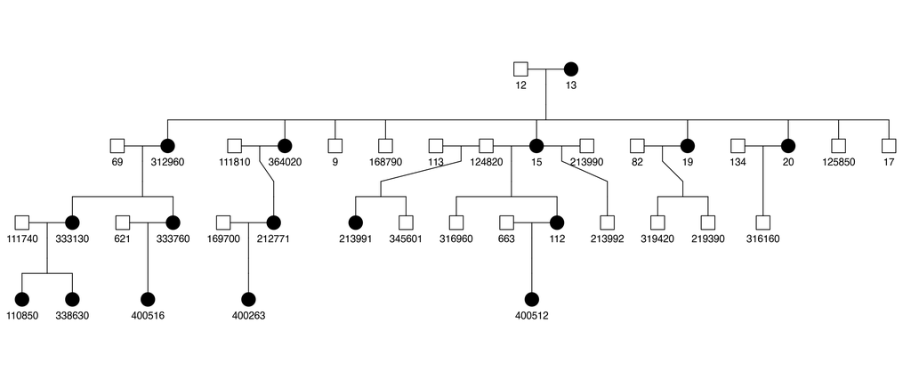

```r
# split out the given maternal lineage and create a pedigree diagram
split_maternal_ped(pedigree = niped, motherID = '13')
```

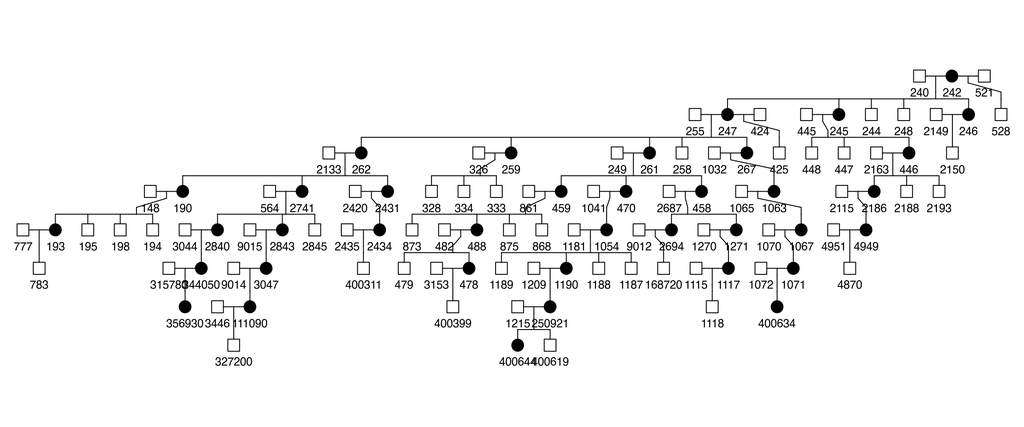

```r
# split out the given maternal lineage and create a pedigree diagram
split_maternal_ped(pedigree = niped, motherID = '242')
```

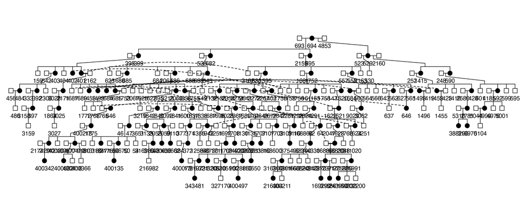

```r
# split out the given maternal lineage and create a pedigree diagram
split_maternal_ped(pedigree = niped, motherID = '694')
```

## Estimating “transmissions”

```r
# get pedigree object
ped_test <- split_maternal_ped(pedigree = niped, motherID = '13')
```

```r
# get number of generations (maternal founder is set to 1)
ped_data <- data.frame(ped_test[[2]], generation = ped_test[[1]]$y)
# create the maternal founder transmission index (number of transmissions from maternal founder to given individual)
ped_data$M0_trans <- ped_data$generation - 1
# filter out new founders that aren't original founders
origFounders <- ped_data %>% filter(M0_trans == 0)  # get original founders
foundersRemoved <- ped_data %>% filter(PID > 0 & MID > 0)  # filter 'new' founders
ped_data <- rbind(origFounders, foundersRemoved)  # recreate ped_data

# now all you need to do is add the `M0_trans` from 2 individuals to get the number of transmissons between them
#
I1 <- "338630"
I2 <- "400512"
# the below will give number of transmissions between the 2
ped_data[ped_data$IID == I1,]$M0_trans + ped_data[ped_data$IID == I2,]$M0_trans
```

```
## [1] 6
```

The above will allow you to explore transmission between a pair of samples defined by the user. If you want to batch process this through all possible pairs in a given pedigree it would look something like this:

```r
# create vector of all ids for selected pedigree
idList <- sort(ped_data$IID)
# create an object of all possible pairwise comparisons
pedPairs <- t(combn(idList, 2))

# create a new matrix of the appropriate dimensions and fill with pairs
# these people don't provie any meaningful maternal information
transMatrix <- matrix(nrow = nrow(pedPairs), ncol = 3)
transMatrix[ , 1] <- pedPairs[ , 1]
transMatrix[ , 2] <- pedPairs[ , 2]
# provide colnames to the matrix
colnames(transMatrix) <- c("ID1", "ID2", "number_of_trans")

# run across all pairs in the above object and fill the 3rd columns of the matrix with
# the number of transmissions between the pair of samples
for (pair in 1:nrow(pedPairs)) {

  # define the pair
  I1 <- pedPairs[pair, 1]
  I2 <- pedPairs[pair, 2]

  # get the number of transmissions and assign to the correct position in the created matrix
  transMatrix[ pair , 3] <- ped_data[ped_data$IID == I1,]$M0_trans + ped_data[ped_data$IID == I2,]$M0_trans

}

# convert to dataframe
transMatrix <- as.data.frame(transMatrix)
# look at random sample of data
sample_n(transMatrix, 10) # sample_n assumes use of dplyr
```

```
##        ID1    ID2 number_of_trans
## 176    112 345601               4
## 72      13 364020               1
## 225 168790 333760               3
## 304 316160 400263               5
## 166    112 213991               4
## 313 316960 400263               5
## 137     19 345601               3
## 293 312960 364020               2
## 129     19 219390               3
## 200 125850 212771               3
```

The above example was run on a small sub-pedigree containing **351** total pairs, it completed in less than a second. Obviously as the number of pairs increases it will take longer. It’s not best practice to use for loops but this was a very quick solution to the problem at hand and it appears to be working well enough for now. Could look into using something like `apply` in the future if required.

```r
# create a function to take maternal ID and generate transmission data for pairs of samples
calc_maternalTrans <- function(maternalFounder) {

  # get pedigree object
  ped_test <- split_maternal_ped(pedigree = niped, motherID = maternalFounder)
  # get number of generations (maternal founder is set to 1)
  ped_data <- data.frame(ped_test[[2]], generation = ped_test[[1]]$y)
  # create the maternal founder transmission index (number of transmissions from maternal founder to given individual)
  ped_data$M0_trans <- ped_data$generation - 1
  # filter out new founders that aren't original founders
  origFounders <- ped_data %>% filter(M0_trans == 0)  # get original founders
  foundersRemoved <- ped_data %>% filter(PID > 0 & MID > 0)  # filter 'new' founders
  ped_data <- rbind(origFounders, foundersRemoved)  # recreate ped_data

  # create vector of all ids for selected pedigree
  idList <- sort(ped_data$IID)
  # create an object of all possible pairwise comparisons
  pedPairs <- t(combn(idList, 2))

  # create a new matrix of the appropriate dimensions and fill with pairs
  # these people don't provie any meaningful maternal information
  transMatrix <- matrix(nrow = nrow(pedPairs), ncol = 4)
  transMatrix[ , 1] <- maternalFounder
  transMatrix[ , 2] <- pedPairs[ , 1]
  transMatrix[ , 3] <- pedPairs[ , 2]
  # provide colnames to the matrix
  colnames(transMatrix) <- c("MaternalFounder", "ID1", "ID2", "number_of_trans")

  # run across all pairs in the above object and fill the 3rd columns of the matrix with
  # the number of transmissions between the pair of samples
  for (pair in 1:nrow(pedPairs)) {

    # define the pair
    I1 <- pedPairs[pair, 1]
    I2 <- pedPairs[pair, 2]

    # get the number of transmissions and assign to the correct position in the created matrix
    transMatrix[ pair , 4] <- ped_data[ped_data$IID == I1,]$M0_trans + ped_data[ped_data$IID == I2,]$M0_trans

  }
  # convert to dataframe
  return(transMatrix <- as.data.frame(transMatrix))
}

# test function
maternalTest <- calc_maternalTrans(13)
```

```r
# look at random sample of data
sample_n(maternalTest, 10) # sample_n assumes use of dplyr
```

```
##     MaternalFounder    ID1    ID2 number_of_trans
## 11               13      9 212771               3
## 40               13     12 312960               1
## 315              13 316960 400516               5
## 118              13     17 400263               4
## 55               13     13     20               1
## 342              13 345601 364020               3
## 9                13      9 125850               2
## 331              13 333760 338630               5
## 305              13 316160 400512               5
## 100              13     17     20               2
```

We can now batch through a list of maternal founders to calculate all pairwise maternal transmissions and return these as an object.

### `for` loop

```r
# list of maternal IDs
maternal_IDs <- c(13, 1597, 691, 694, 242)

# for loop method
maternalTransmissions <- NULL  # define blank object

for (i in maternal_IDs) {

  maternalTransmissions <- rbind(maternalTransmissions, calc_maternalTrans(i))

}
```

```r
# list of maternal IDs
maternal_IDs <- c(13, 1597, 691, 694, 242, 490, 522)
# if you want to use lapply and wrangle back into dataframe
maternalTransmissions <- lapply(maternal_IDs, calc_maternalTrans) %>% do.call(rbind, .)
```

[figure not shown]

[figure not shown]

[figure not shown]

[figure not shown]

[figure not shown]

[figure not shown]

```r
#
sample_n(maternalTransmissions, 10)
```

```
##       MaternalFounder    ID1    ID2 number_of_trans
## 65248             691   2345 400785              11
## 21028             691    449 400107               9
## 81079             694    562 344330               9
## 45006             691   1087   1669              11
## 39867             691    897 311160              13
## 76324             691 332031 400232              15
## 6714              691    151   4886               8
## 39034             691    859 269400              14
## 39426             691    896   1175              10
## 65949             691   2420 312801              12
```

In the above there is no obvious difference in time take between using the `for` loop and `lapply` (only test on a small number so this might change with larger numbers of maternal founders).

We can now look at the breakdown of statistics across this transmission object:

```r
# number of maternal transmissions per founder
table(maternalTransmissions$MaternalFounder)
```

```
##
##    13   242   490   522   691   694  1597
##   351  2556   253   136 76636 14196   351
```

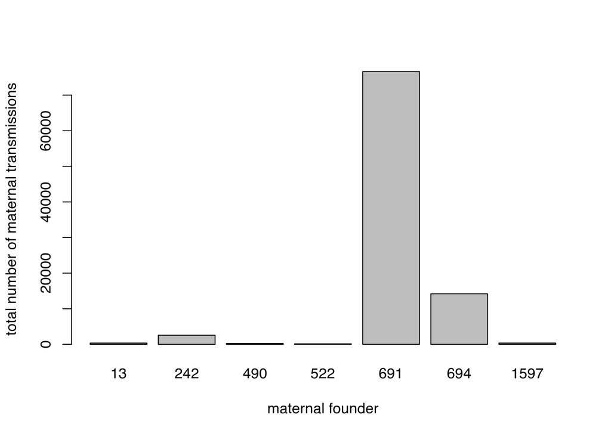

```r
# or a plot
barplot(table(maternalTransmissions$MaternalFounder), xlab = "maternal founder", ylab = "total number of maternal transmissions")
```

```r
# number of total transmissions broken down into category
table(maternalTransmissions$number_of_trans)
```

```
##
##     0     1     2     3     4     5     6     7     8     9    10    11
##    13    80   261   677  1260  2419  4097  6177  8553 11168 12872 13189
##    12    13    14    15    16    17    18    19    20
## 11778  9399  6434  3669  1659   579   162    30     3
```

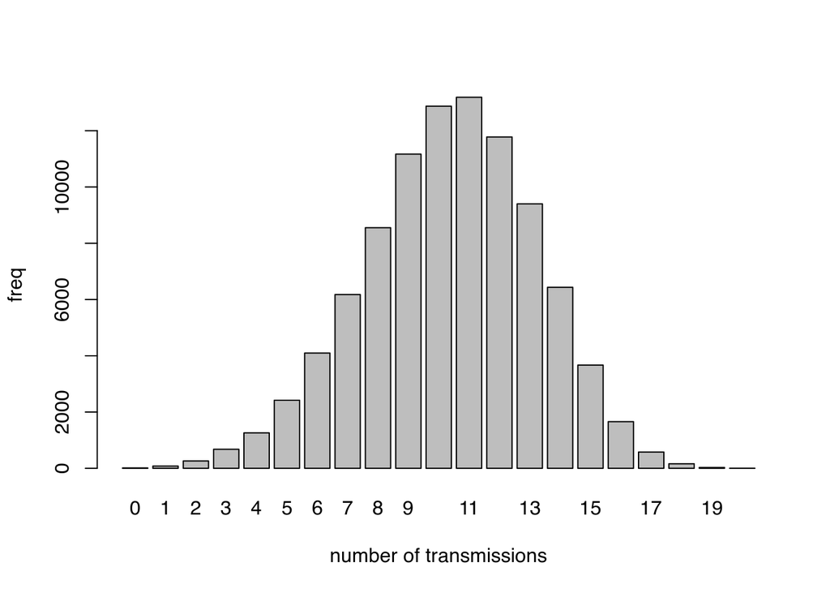

```r
# or a plot
barplot(table(maternalTransmissions$number_of_trans), xlab = "number of transmissions", ylab = "freq")
```

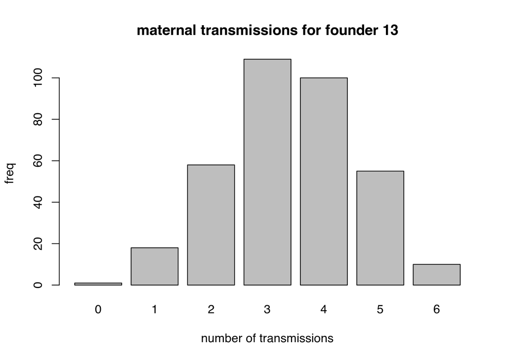

```r
# can also look at a similar plot for a specific founder
# 13
barplot(table(maternalTransmissions[maternalTransmissions$MaternalFounder == 13,]$number_of_trans),
        main = "maternal transmissions for founder 13",
        xlab = "number of transmissions", ylab = "freq")
```

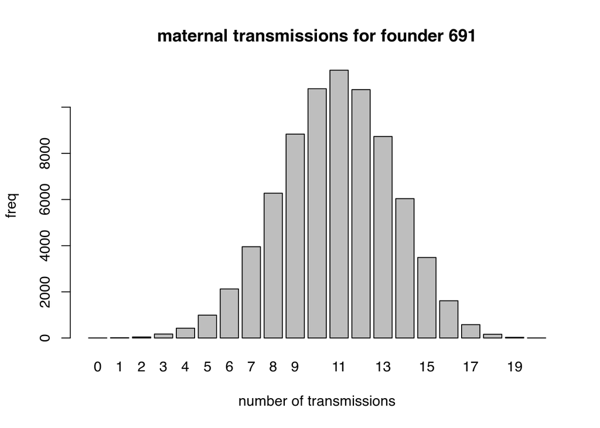

```r
# 691
barplot(table(maternalTransmissions[maternalTransmissions$MaternalFounder == 691,]$number_of_trans),
        main = "maternal transmissions for founder 691",
        xlab = "number of transmissions", ylab = "freq")
```

We can now create a unique ‘key’ by combining the three different ids and then this can be used to pull out information from pairs of interest:

```r
# create a unique id based on the 3 different ids
maternalTransmissions$UUID <- with(maternalTransmissions, paste0(MaternalFounder, ID1, ID2))

# take a random sample of these unique ids
testID <- sample(maternalTransmissions$UUID, 50)

# subset these from the larger data
maternalTransmissions[maternalTransmissions$UUID %in% testID,]
```

```
##       MaternalFounder    ID1    ID2 number_of_trans            UUID
## 1306              691     31   1927               9       691311927
## 7432              691    161   2354               8      6911612354
## 10007             691    252   2114               5      6912522114
## 10236             691    253    644               5       691253644
## 10699             691    255   1616               9      6912551616
## 10722             691    255   1896               7      6912551896
## 10742             691    255   2124               6      6912552124
## 13620             691    326   2111               4      6913262111
## 18266             691    414 310040              11    691414310040
## 22771             691    456    821               8       691456821
## 22908             691    456   2578               9      6914562578
## 23552             691    475   2228              10      6914752228
## 25671             691    532    644               4       691532644
## 27035             691    537   1576              10      6915371576
```

[output cut: 36 more lines]

Where I have taken a random sample of unique ids you can load in your own from something like a text or excel file.